# Machine Learning Coursera project

Savita Kohli

April 7, 2018

## Practical Machine Learning Project : Prediction Assignment Writeup

### Overview:

#### Human Activity Recognition - HAR - has emerged as a key research area in the last years and is gaining increasing attention by the pervasive computing research community, especially for the development of context-aware systems. There are many potential applications for HAR, like: elderly monitoring, life log systems for monitoring energy expenditure and for supporting weight-loss programs, and digital assistants for weight lifting exercises.

#### Using devices such as Jawbone Up, Nike FuelBand, and Fitbit it is now possible to collect a large amount of data about personal activity relatively inexpensively. These type of devices are part of the quantified self movement - a group of enthusiasts who take measurements about themselves regularly to improve their health, to find patterns in their behavior, or because they are tech geeks. One thing that people regularly do is quantify how much of a particular activity they do, but they rarely quantify how well they do it. In this project, your goal will be to use data from accelerometers on the belt, forearm, arm, and dumbell of 6 participants. They were asked to perform barbell lifts correctly and incorrectly in 5 different ways.

#### Data being analyzed here is downloaded from https://d396qusza40orc.cloudfront.net/predmachlearn/. Original source of data is http://web.archive.org/web/20161224072740/http:/groupware.les.inf.puc-rio.br/har.

#### The goal of this project is to predict the manner in which they did the exercise. Outcome is ‘classe’ variable in the training set.

### Loading libraries

```r
library(caret)
library(rpart)
library(rpart.plot)
library(RColorBrewer)
library(rattle)
library(randomForest)
library(knitr)
```

### 1. Load data into R and create partitions of the data

```r
training <- read.csv("https://d396qusza40orc.cloudfront.net/predmachlearn/pml-training.csv", na.strings=c("NA","#DIV/0!",""))
testing <- read.csv("https://d396qusza40orc.cloudfront.net/predmachlearn/pml-testing.csv", na.strings=c("NA","#DIV/0!",""))

inTrain <- createDataPartition(training$classe, p=0.7, list=FALSE)
myTraining <- training[inTrain, ]
myTesting <- training[-inTrain, ]
dim(myTraining); dim(myTesting)
```

```
## [1] 13737   160
```

```
## [1] 5885  160
```

### 2. Preprocessing data by removing columns with more than 95% NAs

```r
nzv <- nearZeroVar(myTraining, saveMetrics = T)
myTraining <- myTraining[, nzv$nzv == FALSE]
NAs <- sapply(myTraining, function(x) sum(is.na(x))/nrow(myTraining)) > .95
myTraining_new <- myTraining[, NAs == FALSE]
## first  column are identification only
myTraining_new <- myTraining_new[, -(1)]
myTesting_New <- myTesting[, names(myTesting) %in% names(myTraining_new)]
dim(myTraining_new) ; dim(myTesting_New)
```

```
## [1] 13737    58
```

```
## [1] 5885   58
```

### 3. Build Multiple models on the training data and

### 4. Use the models to predict on Testing data (30% of population)

#### Model rpart - fit classification tree as a model

```r
trControl <- trainControl(method="cv", number=3)

model_rpart <- rpart(classe ~ ., data=myTraining_new, method="class")
trainpred_rpart <- predict(model_rpart, myTesting_New, type = "class")
confMat_rpart <- confusionMatrix(trainpred_rpart, myTesting_New$classe)
```

#### rf (random forest algorithm)

[figure not shown]

```r
model_RF <- randomForest::randomForest(classe ~ ., data = myTraining_new)
trainpred_RF <- predict(model_RF,newdata=myTesting_New)
confMatRF <- confusionMatrix(trainpred_RF, myTesting_New$classe)
fancyRpartPlot(model_rpart)
```

```r
confMatRF$table
```

```
##           Reference
## Prediction    A    B    C    D    E
##          A 1674    0    0    0    0
##          B    0 1139    0    0    0
##          C    0    0 1026    2    0
##          D    0    0    0  960    0
##          E    0    0    0    2 1082
```

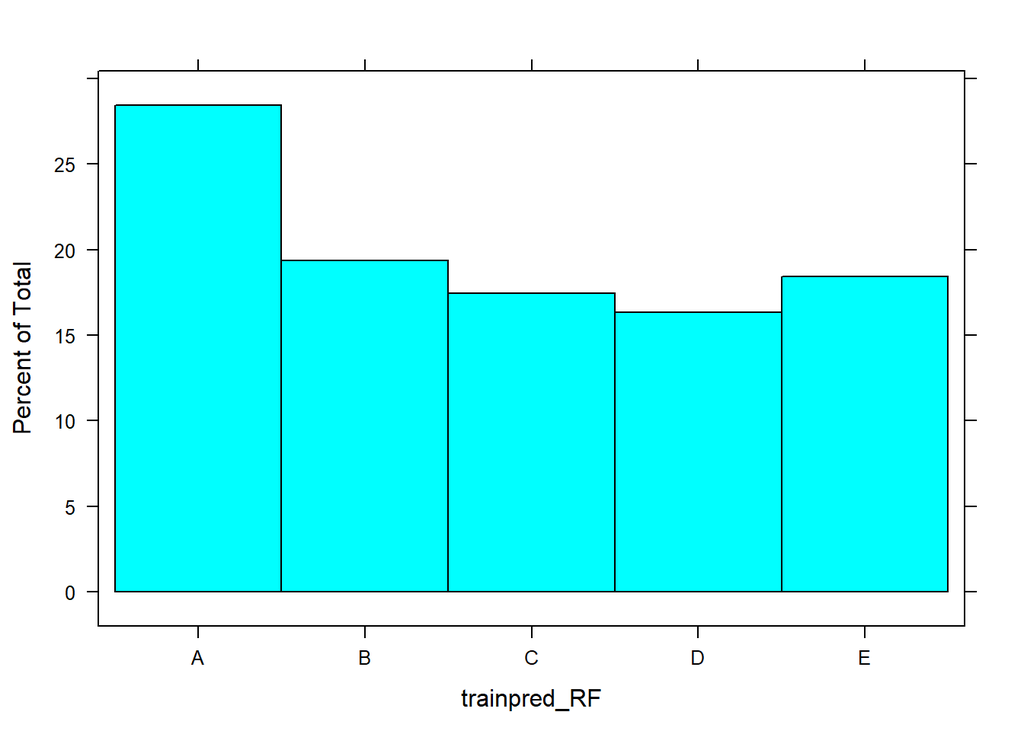

[figure not shown]

```r
histogram(trainpred_RF); plot(model_RF,main="Accuracy of Random forest model by number of predictors")
```

#### lda (linear discriminant analysis) model

```r
model_LDA <- train(classe~., data=myTraining_new, method="lda", trControl=trControl, verbose=FALSE)
trainpred_LDA <- predict(model_LDA,newdata=myTesting_New)
confMatLDA <- confusionMatrix(myTesting_New$classe,trainpred_LDA)
confMatLDA$table
```

```
##           Reference
## Prediction    A    B    C    D    E
##          A 1502  149   22    0    1
##          B  123  868  139    9    0
##          C    3  104  891   26    2
##          D    0    0   92  812   60
##          E    0    0    6   98  978
```

```r
##confMatLDA$overall
```

#### gbm (boosting model)

```r
model_GBM <- train(classe~., data=myTraining_new, method="gbm", trControl=trControl, verbose=FALSE)
trainpred_GBM <- predict(model_GBM,newdata=myTesting_New)
confMatGBM <- confusionMatrix(myTesting_New$classe,trainpred_GBM)
confMatGBM$table
```

```
##           Reference
## Prediction    A    B    C    D    E
##          A 1674    0    0    0    0
##          B    1 1135    3    0    0
##          C    0    1 1017    8    0
##          D    0    0    2  951   11
##          E    0    0    0    2 1080
```

```r
##confMatGBM$overall
```

#### Display and compare accuracy of 4 models

```r
cbind(rpart = confMat_rpart$overall[1],RandomForest = confMatRF$overall[1], LDA = confMatLDA$overall[1], GBM = confMatGBM$overall[1] )
```

```
##              rpart RandomForest       LDA       GBM
## Accuracy 0.8902294    0.9993203 0.8582838 0.9952421
```

```r
testing$classe <- predict(model_GBM, testing)
testing$classe
```

```
##  [1] B A B A A E D B A A B C B A E E A B B B
## Levels: A B C D E
```